# Fraud Detection Using iForest and PCA

### Linh Le

```python
import pandas as pd
import numpy as np
import matplotlib.pyplot as plt
from pyod.models.pca import PCA
from mpl_toolkits.mplot3d import Axes3D
from pyod.models.iforest import IForest
from sklearn.model_selection import train_test_split
!pip install combo
import warnings
warnings.filterwarnings("ignore", category=UserWarning, module='pandas')
import warnings
warnings.filterwarnings(
    "ignore",
    message="X has feature names, but IsolationForest was fitted without feature names",
    category=UserWarning
)
```

```python
data=pd.read_csv('/Users/linhle/Downloads/purchase_credit_card.csv')
```

```python
data.head(10)
```

|  | Year-Month | Agency Number | Agency Name | Cardholder Last Name | Cardholder First Initial | Description | Amount | Vendor | Transaction Date | Posted Date | Merchant Category Code (MCC) |
| --- | --- | --- | --- | --- | --- | --- | --- | --- | --- | --- | --- |
| 0 | 201307 | 1000 | OKLAHOMA STATE UNIVERSITY | Mason | C | GENERAL PURCHASE | 890.00 | NACAS | 07/30/2013 12:00:00 AM | 07/31/2013 12:00:00 AM | CHARITABLE AND SOCIAL SERVICE ORGANIZATIONS |
| 1 | 201307 | 1000 | OKLAHOMA STATE UNIVERSITY | Mason | C | ROOM CHARGES | 368.96 | SHERATON HOTEL | 07/30/2013 12:00:00 AM | 07/31/2013 12:00:00 AM | SHERATON |
| 2 | 201307 | 1000 | OKLAHOMA STATE UNIVERSITY | Massey | J | GENERAL PURCHASE | 165.82 | SEARS.COM 9300 | 07/29/2013 12:00:00 AM | 07/31/2013 12:00:00 AM | DIRCT MARKETING/DIRCT MARKETERS--NOT ELSEWHERE... |
| 3 | 201307 | 1000 | OKLAHOMA STATE UNIVERSITY | Massey | T | GENERAL PURCHASE | 96.39 | WAL-MART #0137 | 07/30/2013 12:00:00 AM | 07/31/2013 12:00:00 AM | GROCERY STORES,AND SUPERMARKETS |
| 4 | 201307 | 1000 | OKLAHOMA STATE UNIVERSITY | Mauro-Herrera | M | HAMMERMILL COPY PLUS COPY EA | 125.96 | STAPLES DIRECT | 07/30/2013 12:00:00 AM | 07/31/2013 12:00:00 AM | STATIONERY, OFFICE SUPPLIES, PRINTING AND WRIT... |
| 5 | 201307 | 1000 | OKLAHOMA STATE UNIVERSITY | Mauro-Herrera | M | GENERAL PURCHASE | 394.28 | KYOCERA DOCUMENT SOLUTION | 07/29/2013 12:00:00 AM | 07/31/2013 12:00:00 AM | OFFICE, PHOTOGRAPHIC, PHOTOCOPY, AND MICROFILM... |
| 6 | 201307 | 1000 | OKLAHOMA STATE UNIVERSITY | Mays | B | GENERAL PURCHASE | 19.87 | WAL-MART #0137 | 07/30/2013 12:00:00 AM | 07/31/2013 12:00:00 AM | GROCERY STORES,AND SUPERMARKETS |
| 7 | 201307 | 1000 | OKLAHOMA STATE UNIVERSITY | Mays | B | GENERAL PURCHASE | 10.10 | DAYLIGHT DONUTS | 07/29/2013 12:00:00 AM | 07/31/2013 12:00:00 AM | FAST FOOD RESTAURANTS |
| 8 | 201307 | 1000 | OKLAHOMA STATE UNIVERSITY | McCarthy | D | GENERAL PURCHASE | 142.60 | UFIRST LAUNDRY SVCS | 07/30/2013 12:00:00 AM | 07/31/2013 12:00:00 AM | MENS, WOMENS AND CHILDRENS UNIFORMS AND COMMER... |
| 9 | 201307 | 1000 | OKLAHOMA STATE UNIVERSITY | McClurg | L | AT&T SERVICE PAYMENT ITM | 29.99 | AT&T DATA | 07/30/2013 12:00:00 AM | 07/31/2013 12:00:00 AM | TELECOMMUNICATION SERVICES |

# Features for Deeper Insights and Analysis

## Feature 1: Agency to Merchant Spending Ratio

```python
import numpy as np
import pandas as pd

stat_by_agency = (
    data.groupby(['Agency Name', 'Merchant Category Code (MCC)'], observed=True)['Amount']
        .mean()
        .reset_index(name='AVG_amount')
)

data = data.merge(
    stat_by_agency,
    on=['Agency Name', 'Merchant Category Code (MCC)'],
    how='left'
)

data['agency_merchant_avg_ratio_amount'] = np.where(
    data['AVG_amount'] == 0, 0, data['Amount'] / data['AVG_amount']
)
```

## Feature 2: Cardholder's Transaction Frequency

```python
data['YearMonth'] = pd.to_datetime(data['Transaction Date']).dt.to_period('M')

txn_freq = (
    data.groupby(['Cardholder Last Name', 'YearMonth'])['Amount']
        .count()
        .reset_index(name='Txn_Frequency')
)

cardholder_avg_freq = (
    txn_freq.groupby('Cardholder Last Name')['Txn_Frequency']
        .mean()
        .reset_index(name='Avg_Txn_Frequency')
)

txn_freq = txn_freq.merge(cardholder_avg_freq, on='Cardholder Last Name', how='left')
txn_freq['Txn_Freq_Ratio'] = txn_freq['Txn_Frequency'] / txn_freq['Avg_Txn_Frequency']

data = data.merge(
    txn_freq[['Cardholder Last Name', 'YearMonth', 'Txn_Freq_Ratio']],
    on=['Cardholder Last Name', 'YearMonth'],
    how='left'
)
```

## Feature 3: Cardholder's Monthly Transaction Amount

```python
data['YearMonth'] = pd.to_datetime(data['Transaction Date']).dt.to_period('M')

monthly_spend = (
    data.groupby(['Cardholder Last Name', 'YearMonth'])['Amount']
        .sum()
        .reset_index(name='Monthly_Spend')
)

cardholder_avg_spend = (
    monthly_spend.groupby('Cardholder Last Name')['Monthly_Spend']
        .mean()
        .reset_index(name='Avg_Monthly_Spend')
)

monthly_spend = monthly_spend.merge(cardholder_avg_spend, on='Cardholder Last Name', how='left')
monthly_spend['Monthly_Spend_Ratio'] = np.where(
    monthly_spend['Avg_Monthly_Spend'] == 0,
    0,
    monthly_spend['Monthly_Spend'] / monthly_spend['Avg_Monthly_Spend']
)

data = data.merge(
    monthly_spend[['Cardholder Last Name', 'YearMonth', 'Monthly_Spend_Ratio']],
    on=['Cardholder Last Name', 'YearMonth'],
    how='left'
)
```

# iForest for Anamoly Detection in the Dataset

Isolation Forest is an unsupervised anomaly detection algorithm that isolates observations by randomly selecting a feature and a split value. The key idea is that anomalies are detected since they have shorter average path lengths in the trees. Hence, the model computes an anomaly score inversely related to the path length. Because the algorithms include several hyperparameters that influence the results, multiple models with different configurations will be trained and their results aggregated to improve robustness and stability. With the large dataset, a 5% anamolies might be too high. Hence, the analysis later defines threshold at 0.5%.

```python
X = data.copy()
drop_cols = [ 'Cardholder First Initial', 'Vendor', 'Description', 'Transaction Date', 'Posted Date', 'Year-Month', 'YearMonth']
X = X.drop(columns=drop_cols, errors='ignore')
```

```python
X['Agency Name'] = X['Agency Name'].astype('category').cat.codes
X['Cardholder Last Name'] = X['Cardholder Last Name'].astype('category').cat.codes
X['Merchant Category Code (MCC)'] = X['Merchant Category Code (MCC)'].astype('category').cat.codes
```

```python
contamination = 0.005
X_train, X_test = train_test_split(
    X,
    test_size=0.3,
    random_state=123
)
```

```python
X_train.head()
X_train.describe()
X_train.dtypes
```

```
Agency Number                         int64
Agency Name                            int8
Cardholder Last Name                  int16
Amount                              float64
Merchant Category Code (MCC)          int16
AVG_amount                          float64
agency_merchant_avg_ratio_amount    float64
Txn_Freq_Ratio                      float64
Monthly_Spend_Ratio                 float64
dtype: object
```

```python
scaler = StandardScaler()
X_train = scaler.fit_transform(X_train)
X_test = scaler.transform(X_test)
```

### Build iForest Model

```python
print(type(X_train))
print(type(X_test))
```

```
<class 'numpy.ndarray'>
<class 'numpy.ndarray'>
```

```python
isft = IForest(contamination=0.05, max_samples=500, behaviour='new')
isft.fit(X_train)

y_train_scores = isft.decision_function(X_train)
y_train_pred = isft.predict(X_train)

y_test_scores = isft.decision_function(X_test)
y_test_pred = isft.predict(X_test)

print("The threshold for the defined contamination rate:" , isft.threshold_)

def count_stat(vector):
    unique, counts = np.unique(vector, return_counts=True)
    return dict(zip(unique, counts))

print("The training data:", count_stat(y_train_pred))
print("The test data:", count_stat(y_test_pred))
```

```
The threshold for the defined contamination rate: -8.280938199492862e-17
The training data: {0: 294234, 1: 15486}
The test data: {0: 126274, 1: 6464}
```

```python
isft.get_params()
```

```
{'behaviour': 'new',
 'bootstrap': False,
 'contamination': 0.05,
 'max_features': 1.0,
 'max_samples': 500,
 'n_estimators': 100,
 'n_jobs': 1,
 'random_state': None,
 'verbose': 0}
```

```python
isft_vi = isft.feature_importances_
isft_vi
```

```
array([0.08974858, 0.09580442, 0.11798123, 0.11981149, 0.10403459,
       0.11492142, 0.12585006, 0.11612582, 0.11572238])
```

```python
isf_predictions = y_test_pred
isf_scores = y_test_by_average
```

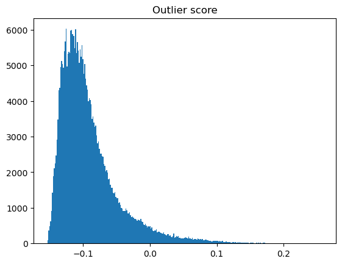

```python
plt.hist(y_train_scores, bins='auto') # arguments are passed to np.histogram
plt.title("Outlier score")
plt.show()
```

```python
import pandas as pd
import numpy as np
import matplotlib.pyplot as plt

feature_list = ['Agency Number', 'Agency Name', 'Cardholder Last Name', 'Amount', 'Merchant Category Code (MCC)']

def count_stat(vector):
    """Count how many 0s and 1s (Normal vs Outlier)."""
    unique, counts = np.unique(vector, return_counts=True)
    return dict(zip(unique, counts))

def descriptive_stat_threshold(df, pred_score, threshold):
    """
    Adds anomaly scores and labels (Normal/Outlier),
    then summarizes by group.
    """
    df = pd.DataFrame(df.copy())
    df.columns = feature_list

    df['Anomaly_Score'] = pred_score
    df['Group'] = np.where(df['Anomaly_Score'] < threshold, 'Normal', 'Outlier')

    cnt = (
        df.groupby('Group')['Anomaly_Score']
        .count()
        .reset_index()
        .rename(columns={'Anomaly_Score': 'Count'})
    )
    cnt['Count %'] = (cnt['Count'] / cnt['Count'].sum()) * 100

    stat = df.groupby('Group').mean(numeric_only=True).round(2).reset_index()
    stat = cnt.merge(stat, on='Group', how='left')
    return stat

def confusion_matrix_threshold(actual, score, threshold):
    """Binary confusion matrix based on threshold cutoff."""
    Actual_pred = pd.DataFrame({'Actual': actual, 'Pred': score})
    Actual_pred['Pred'] = np.where(Actual_pred['Pred'] <= threshold, 0, 1)
    cm = pd.crosstab(Actual_pred['Actual'], Actual_pred['Pred'])
    return cm

def confusion_matrix(actual, pred):
    """Standard confusion matrix between actual and predicted labels."""
    Actual_pred = pd.DataFrame({'Actual': actual, 'Pred': pred})
    cm = pd.crosstab(Actual_pred['Actual'], Actual_pred['Pred'])
    return cm
```

```python
threshold = isft.threshold_
feature_list = ['Feature_1','Feature_2','Feature_3','Feature_4','Feature_5', 'Feature_6', 'Feature_7', 'Feature_8', 'Feature_9']
descriptive_stat_threshold(X_train,y_train_scores, threshold)
```

|  | Group | Count | Count % | Feature_1 | Feature_2 | Feature_3 | Feature_4 | Feature_5 | Feature_6 | Feature_7 | Feature_8 | Feature_9 | Anomaly_Score |
| --- | --- | --- | --- | --- | --- | --- | --- | --- | --- | --- | --- | --- | --- |
| 0 | Normal | 294234 | 95.0 | -0.01 | 0.02 | 0.01 | -0.04 | 0.00 | -0.06 | -0.03 | -0.06 | -0.08 | -0.10 |
| 1 | Outlier | 15486 | 5.0 | 0.13 | -0.35 | -0.10 | 0.69 | -0.01 | 1.20 | 0.61 | 1.22 | 1.43 | 0.05 |

```python
descriptive_stat_threshold(X_test,y_test_scores, threshold)
```

|  | Group | Count | Count % | Feature_1 | Feature_2 | Feature_3 | Feature_4 | Feature_5 | Feature_6 | Feature_7 | Feature_8 | Feature_9 | Anomaly_Score |
| --- | --- | --- | --- | --- | --- | --- | --- | --- | --- | --- | --- | --- | --- |
| 0 | Normal | 126274 | 95.130257 | -0.01 | 0.02 | 0.01 | -0.04 | 0.00 | -0.06 | -0.03 | -0.06 | -0.08 | -0.10 |
| 1 | Outlier | 6464 | 4.869743 | 0.15 | -0.35 | -0.12 | 0.76 | 0.02 | 1.24 | 0.50 | 1.16 | 1.37 | 0.05 |

```python
count_stat(y_train_pred)
count_stat(y_test_pred)
```

```
{0: 126274, 1: 6464}
```

### Calculate Averages

```python
from pyod.utils.utility import standardizer
param_grid = {
    "n_estimators": [300, 400, 600],
    "max_samples": [128, 256, 512],
    "max_features": [0.6, 0.8, 1.0]
}

models = []
for n in param_grid["n_estimators"]:
    for s in param_grid["max_samples"]:
        for f in param_grid["max_features"]:
            model = IForest(
                contamination=0.05,
                n_estimators=n,
                max_samples=s,
                max_features=f,
                random_state=42,
                n_jobs=-1,
            ).fit(X_train)
            models.append(model)

train_scores = np.column_stack([m.decision_function(X_train) for m in models])
test_scores = np.column_stack([m.decision_function(X_test) for m in models])
train_scores_norm, test_scores_norm = standardizer(train_scores, test_scores)
```

```python
from pyod.models.combination import aom, moa, average, maximization
y_train_by_average = average(train_scores_norm)
y_test_by_average = average(test_scores_norm)
```

```python
descriptive_stat_threshold(X_test,y_test_by_average, 1.5)
```

|  | Group | Count | Count % | Feature_1 | Feature_2 | Feature_3 | Feature_4 | Feature_5 | Feature_6 | Feature_7 | Feature_8 | Feature_9 | Anomaly_Score |
| --- | --- | --- | --- | --- | --- | --- | --- | --- | --- | --- | --- | --- | --- |
| 0 | Normal | 122294 | 92.131869 | -0.01 | 0.03 | 0.01 | -0.04 | 0.00 | -0.08 | -0.04 | -0.08 | -0.11 | -0.22 |
| 1 | Outlier | 10444 | 7.868131 | 0.09 | -0.38 | -0.08 | 0.53 | 0.02 | 0.95 | 0.39 | 0.87 | 1.14 | 2.49 |

```python
import numpy as np
import pandas as pd


def top_outliers(df, scores, cutoff=0.5, model_name="IForest_Avg"):
    """
    Identify top outliers based on (possibly averaged) anomaly scores.

    Parameters
    ----------
    df : pd.DataFrame
        Original dataset (e.g., X_test)
    scores : np.array
        Anomaly scores from averaged model results (e.g., y_test_iforest_avg)
    cutoff : float
        Percentage of top anomalies to keep (e.g., 0.5 = top 0.5%)
    model_name : str
        Optional name prefix for output columns (e.g., "IForest_Avg" or "PCA")

    Returns
    -------
    outliers_df : pd.DataFrame
        Subset of df containing only the top anomalies,
        with '{model_name}_Score' and '{model_name}_Label' columns.
    """

    scores = np.asarray(scores).ravel()

    if not isinstance(df, pd.DataFrame):
        df = pd.DataFrame(df)

    threshold = np.percentile(scores, 100 - cutoff)

    df = df.copy()
    df[f"{model_name}_Score"] = scores
    df[f"{model_name}_Label"] = (scores >= threshold).astype(int)

    outliers = df[df[f"{model_name}_Label"] == 1].sort_values(f"{model_name}_Score", ascending=False)

    print(f"✅ Model: {model_name}")
    print(f"Top {cutoff}% anomalies: {len(outliers)} out of {len(df)} total records")
    print(f"Threshold ({model_name}_Score): {threshold:.6f}\n")

    return outliers
```

```python
X_test_with_scores = pd.DataFrame(X_test_scaled)

scores_1d = np.ravel(y_test_scores)

X_test_with_scores['Anomaly_Score'] = scores_1d
X_test_with_scores['Anomaly_Label'] = (scores_1d >= np.percentile(scores_1d, 99.5)).astype(int)

print(f"Total anomalies: {X_test_with_scores['Anomaly_Label'].sum()} / {len(X_test_with_scores)}")
X_test_with_scores[X_test_with_scores['Anomaly_Label'] == 1].head(10)
```

```
Total anomalies: 664 / 132738
```

|  | 0 | 1 | 2 | 3 | 4 | Anomaly_Score | Anomaly_Label |
| --- | --- | --- | --- | --- | --- | --- | --- |
| 70 | 2.433109 | 0.175435 | 2.741390 | -1.659057 | -1.631113 | 0.157882 | 1 |
| 540 | 3.953511 | 1.822045 | 1.033292 | 0.001362 | -0.191564 | 0.128082 | 1 |
| 952 | -0.080667 | 16.715152 | -0.150701 | 2.182539 | 2.955238 | 0.143141 | 1 |
| 1103 | 1.187511 | 0.220171 | 1.205547 | 2.335294 | 0.489757 | 0.105784 | 1 |
| 1223 | 3.860463 | 2.079178 | 0.885519 | -0.586630 | -0.630039 | 0.125654 | 1 |
| 2175 | 0.960067 | -0.158403 | 2.789901 | 0.496239 | 0.756765 | 0.121377 | 1 |
| 2191 | 1.240966 | 0.018020 | 1.963389 | 4.574742 | -0.619031 | 0.163024 | 1 |
| 2198 | 1.257869 | 4.764904 | 0.018290 | -0.423121 | 0.047728 | 0.109470 | 1 |
| 2479 | 12.643704 | 0.247888 | 12.791011 | 0.197348 | 0.902969 | 0.170286 | 1 |
| 2690 | -0.087404 | -0.389368 | 6.284452 | 4.077454 | -0.871544 | 0.134581 | 1 |

```python
num_anomalies = X_test_with_scores['Anomaly_Label'].sum()
print(f"Total anomalies: {num_anomalies}")
```

```
Total anomalies: 664
```

```python
X_test_with_scores[X_test_with_scores['Anomaly_Label'] == 1]\
    .sort_values('Anomaly_Score', ascending=False)\
    .head(20)
```

|  | 0 | 1 | 2 | 3 | 4 | Anomaly_Score | Anomaly_Label |
| --- | --- | --- | --- | --- | --- | --- | --- |
| 46511 | 369.226478 | 16.715152 | 13.838118 | -1.286154 | 0.223619 | 0.256620 | 1 |
| 21282 | 229.718801 | 8.281782 | 17.019689 | 0.241904 | 1.653164 | 0.239944 | 1 |
| 104175 | 85.044091 | 8.554347 | 6.016083 | 0.241904 | 1.653164 | 0.239490 | 1 |
| 109254 | 57.250233 | 4.592103 | 7.306401 | 0.121633 | 0.367026 | 0.239293 | 1 |
| 5680 | 49.286654 | 4.592103 | 6.270676 | 0.121633 | 0.367026 | 0.239293 | 1 |
| 76346 | 72.740166 | 15.777803 | 2.767589 | -0.573266 | -0.333263 | 0.237557 | 1 |
| 47040 | 12.387995 | 0.595334 | 8.057061 | 2.160286 | 7.477172 | 0.234654 | 1 |
| 102439 | 32.766168 | 4.592103 | 4.122060 | 0.121633 | 0.367026 | 0.233330 | 1 |
| 20535 | 27.761809 | 15.777803 | 0.965096 | -0.020512 | 2.078205 | 0.222052 | 1 |
| 122193 | 12.333044 | 10.594450 | 0.581711 | 0.543986 | 6.321578 | 0.221869 | 1 |
| 118890 | 22.064671 | 4.592103 | 2.730248 | 0.001362 | -0.191564 | 0.221140 | 1 |
| 85618 | 27.689814 | 8.281782 | 1.924555 | -0.907352 | -0.704634 | 0.220440 | 1 |
| 35161 | 72.312380 | 157.005309 | 0.147014 | -0.448884 | 0.900804 | 0.217301 | 1 |
| 41059 | 3.624997 | 0.239285 | 3.675744 | 1.530120 | 4.415805 | 0.210444 | 1 |
| 15535 | 12.015924 | 17.078148 | 0.297972 | -0.452995 | 0.233434 | 0.209074 | 1 |
| 55942 | 8.880873 | 0.220171 | 9.380817 | 1.816673 | 4.531693 | 0.208411 | 1 |
| 98976 | 11.799816 | 0.508453 | 8.426830 | 3.043732 | 3.011245 | 0.207463 | 1 |
| 39228 | 5.518436 | 10.021325 | 0.197954 | 1.644294 | 6.135839 | 0.205596 | 1 |
| 111057 | 11.777986 | 18.253894 | 0.261388 | 0.713334 | -0.097880 | 0.202705 | 1 |
| 125856 | 11.585288 | -0.138801 | 30.015404 | -0.713285 | 8.609405 | 0.202618 | 1 |

```python
data_with_anomalies = pd.concat(
    [data.reset_index(drop=True), X_test_with_scores[['Anomaly_Score', 'Anomaly_Label']]],
    axis=1
)

outliers = data_with_anomalies[data_with_anomalies['Anomaly_Label'] == 1]

outliers_sorted = outliers.sort_values('Anomaly_Score', ascending=False)

total_anomalies = len(outliers_sorted)
total_records = len(data_with_anomalies)
print(f"Total anomalies: {total_anomalies:,} / {total_records:,} ({(total_anomalies/total_records)*100:.2f}%)")

outliers_sorted[['Agency Name',
                 'Cardholder Last Name',
                 'Amount',
                 'Merchant Category Code (MCC)',
                 'Vendor',
                 'Anomaly_Score']].head(15)
```

```
Total anomalies: 664 / 442,458 (0.15%)
```

|  | Agency Name | Cardholder Last Name | Amount | Merchant Category Code (MCC) | Vendor | Anomaly_Score |
| --- | --- | --- | --- | --- | --- | --- |
| 46511 | OKLAHOMA STATE UNIVERSITY | Hanson | 229.25 | OFFICE, PHOTOGRAPHIC, PHOTOCOPY, AND MICROFILM... | XEROX CORPORATION/RBO | 0.256620 |
| 21282 | OKLAHOMA STATE UNIVERSITY | Heusel | 715.00 | STATIONERY, OFFICE SUPPLIES, PRINTING AND WRIT... | XPEDX-INTL PAPER | 0.239944 |
| 104175 | STATE DEPARTMENT OF HEALTH | Duren | 736.00 | COMPUTERS, COMPUTER PERIPHERAL EQUIPMENT, SOFT... | SHI CORP | 0.239490 |
| 109254 | DEPARTMENT OF TRANSPORTATION | HARGUS | 67.33 | CONSTRUCTION MATERIALS NOT ELSEWHERE CLASSIFIED | LAMPTON WELDING SUPPLY | 0.239293 |
| 5680 | OKLAHOMA STATE UNIVERSITY | Hull | 34.85 | BOOK STORES | Amazon.com | 0.239293 |
| 76346 | OFFICE OF MANAGEMENT AND ENTERPRISE SERV | Vanhorn | 53.72 | STATIONERY, OFFICE SUPPLIES, PRINTING AND WRIT... | STAPLES | 0.237557 |
| 47040 | OKLAHOMA STATE UNIVERSITY | Goad | 378.00 | EATING PLACES AND RESTAURANTS | LAKE HEFNER GOLF COURS | 0.234654 |
| 102439 | DEPARTMENT OF WILDLIFE CONSERVATION | Banta | 69.99 | CABLE, SATELLITE, AND OTHER PAY TELEVISION AND... | HNS HughesNet.com | 0.233330 |
| 20535 | OKLAHOMA STATE UNIVERSITY | Brinker | 35.99 | CABLE, SATELLITE, AND OTHER PAY TELEVISION AND... | DTV DIRECTV SERVICE | 0.222052 |
| 122193 | LANGSTON UNIVERSITY | Stevenson | 721.60 | AMERICAN AIRLINES | AMERICAN AI 0017311538849 | 0.221869 |
| 118890 | COMPSOURCE OKLAHOMA | Janey | 333.00 | STATIONERY, OFFICE SUPPLIES, PRINTING AND WRIT... | STAPLES | 0.221140 |
| 85618 | DEPARTMENT OF CORRECTIONS | Bowlin | 1015.00 | CATALOG MERCHANTS | GALLS/QUARTERMASTER | 0.220440 |
| 35161 | OKLAHOMA STATE UNIVERSITY | Davis | 62.39 | HOME SUPPLY WAREHOUSE STORES | LOWES #00241 | 0.217301 |
| 41059 | OKLAHOMA STATE UNIVERSITY | Estes | 19.94 | BOOKS, PERIODICALS AND NEWSPAPERS | ABEBOOKS.COM | 0.210444 |
| 15535 | OKLAHOMA STATE UNIVERSITY | Heusel | 713.77 | INDUSTRIAL SUPPLIES NOT ELSEWHERE CLASSIFIED | WW GRAINGER | 0.209074 |

```python
isf_pred_saved = y_test_pred.copy()
isf_scores_saved = y_test_by_average.copy()

print("Isolation Forest saved:")
print(f"  Predictions: {isf_pred_saved[:10]}")
print(f"  Scores: {isf_scores_saved[:10]}")
```

```
Isolation Forest saved:
  Predictions: [0 0 0 0 0 0 0 0 0 0]
  Scores: [-0.59061324 -0.42692495  0.14085462 -1.32421577  0.21474653 -0.56655891
 -0.28744242 -0.29412912  0.32016936  0.93163152]
```

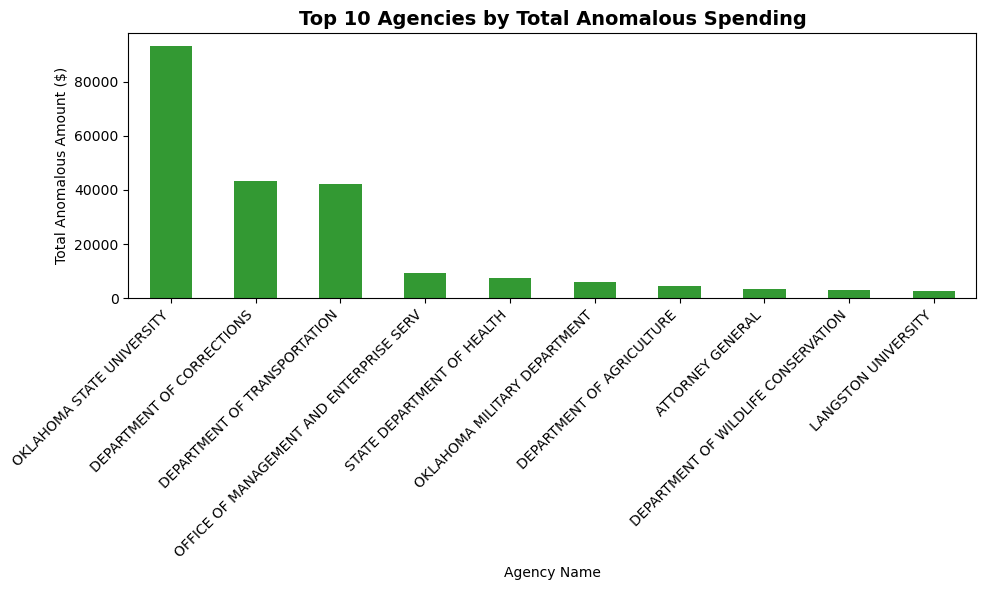

```python
import matplotlib.pyplot as plt

agency_anomaly = (
    outliers.groupby('Agency Name')['Amount']
    .sum()
    .sort_values(ascending=False)
    .head(10)
)

plt.figure(figsize=(10, 6))
agency_anomaly.plot(kind='bar', color='green', alpha=0.8)
plt.title("Top 10 Agencies by Total Anomalous Spending", fontsize=14, weight='bold')
plt.ylabel("Total Anomalous Amount ($)")
plt.xlabel("Agency Name")
plt.xticks(rotation=45, ha='right')
plt.tight_layout()
plt.show()
```

## **Business Insights**

**Oklahoma State University stands out as the agencies with the most anamolous amount**

**Anomalies cluster in administrative and operations-heavy agencies**

**Vendor concentration suggests possible recurring irregularities**

Several anomalies are repeatedly linked to vendors like Staples, SHI Corp, Xerox, and Amazon.com. These agencies are all office suppliers. While none are inherently suspicious vendors, the concentration indicates potential overuse of general supply contracts or misclassified purchases.

**Service and utility-type expenses show unexpected spikes**

# PCA for Anamoly Detection in the dataset

Principal Component Analysis (PCA) is a statistical technique used to reduce the dimensionality of data by representing many variables with a smaller number of components. PCA groups together variables that show similar patterns, typically by measuring their correlations. Each principal component shows a direction of maximum variance in the data. Points that align closely with a given component are strongly correlated with that component. Anomalous points can then be identified as those that are farther away from the principal component axis. With the large dataset, a 5% anamolies might be too high. Hence, the analysis later defines threshold at 0.5%.

```python
from pyod.models.pca import PCA
features_for_pca = [
    'Amount',
    'AVG_amount',
    'agency_merchant_avg_ratio_amount',
    'Txn_Freq_Ratio',
    'Monthly_Spend_Ratio'
]

X_train = pd.DataFrame(X_train_scaled, columns=features_for_pca)
X_test  = pd.DataFrame(X_test_scaled,  columns=features_for_pca)

X_train= X_train[features_for_pca].copy()
X_test= X_test[features_for_pca].copy()

pca = PCA(contamination=0.05)
pca.fit(X_train)

y_train_pred = pca.labels_
y_train_scores = pca.decision_scores_
y_train_scores = pca.decision_function(X_train)
y_train_pred = pca.predict(X_train)

y_test_scores = pca.decision_function(X_test)
y_test_pred = pca.predict(X_test)
```

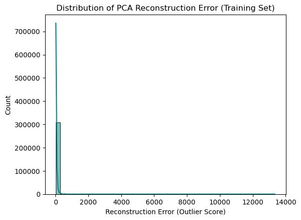

```
Score range: 26.70947376324877 to 13340.704388980239
```

```python
import matplotlib.pyplot as plt
import seaborn as sns

y_scores = y_train_scores
sns.histplot(y_scores, bins=50, kde=True, color='teal')
plt.title("Distribution of PCA Reconstruction Error (Training Set)")
plt.xlabel("Reconstruction Error (Outlier Score)")
plt.show()

print("Score range:", y_scores.min(), "to", y_scores.max())
```

```python
pca.get_params()
```

```
{'contamination': 0.05,
 'copy': True,
 'iterated_power': 'auto',
 'n_components': None,
 'n_selected_components': None,
 'random_state': None,
 'standardization': True,
 'svd_solver': 'auto',
 'tol': 0.0,
 'weighted': True,
 'whiten': False}
```

```python
[pca.explained_variance_,
pca.explained_variance_ratio_]
```

```
[array([1.6398331 , 1.26872482, 1.00060996, 0.73147028, 0.35937798]),
 array([0.32796556, 0.25374414, 0.20012135, 0.14629358, 0.07187536])]
```

```python
print("The threshold for the defined contamination rate:" , pca.threshold_)
```

```
The threshold for the defined contamination rate: 101.98290776995186
```

```python
X_test["PCA_Score"] = y_test_scores
X_test["PCA_Label"] = y_test_pred
outliers = X_test[X_test["PCA_Label"] == 1]
```

```python
pca_predictions = y_test_pred.copy()
pca_scores = y_test_scores.copy()
```

```python
outliers.sort_values("PCA_Score", ascending=False).head(10)
```

|  | Amount | AVG_amount | agency_merchant_avg_ratio_amount | Txn_Freq_Ratio | Monthly_Spend_Ratio | PCA_Score | PCA_Label |
| --- | --- | --- | --- | --- | --- | --- | --- |
| 14374 | -0.197315 | -0.389366 | -407.921230 | -0.113975 | -1.875068 | 13356.956560 | 1 |
| 46511 | 369.226478 | 16.715152 | 13.838118 | -1.286154 | 0.223619 | 12100.553753 | 1 |
| 21282 | 229.718801 | 8.281782 | 17.019689 | 0.241904 | 1.653164 | 7538.275016 | 1 |
| 35161 | 72.312380 | 157.005309 | 0.147014 | -0.448884 | 0.900804 | 5659.537045 | 1 |
| 42108 | -0.069948 | 157.005309 | -0.150941 | -0.448884 | -1.505814 | 5144.407907 | 1 |
| 120950 | -0.125165 | -0.389366 | -136.074423 | -1.255144 | -1.286337 | 4458.197979 | 1 |
| 89755 | 12.570410 | 94.821988 | -0.064874 | -0.105546 | -0.363624 | 3134.722934 | 1 |
| 22663 | 2.020827 | 94.821988 | -0.136662 | 0.054815 | -0.710889 | 3109.237780 | 1 |
| 28693 | 1.189204 | 94.821988 | -0.142321 | 0.241904 | 1.653164 | 3108.955071 | 1 |
| 81219 | -0.047418 | 94.821988 | -0.150736 | -0.182479 | -0.481894 | 3108.603789 | 1 |

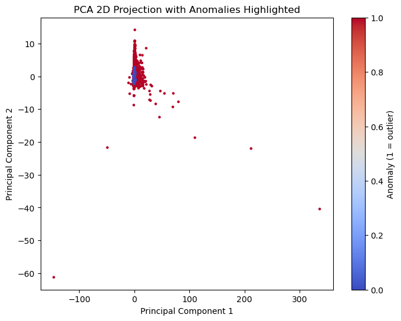

```python
from sklearn.decomposition import PCA as SKPCA
import matplotlib.pyplot as plt

pca_2d = SKPCA(n_components=2)
X_pca = pca_2d.fit_transform(X_test_scaled)

plt.figure(figsize=(8,6))
plt.scatter(X_pca[:,0], X_pca[:,1], c=y_test_pred, cmap="coolwarm", s=5)
plt.title("PCA 2D Projection with Anomalies Highlighted")
plt.xlabel("Principal Component 1")
plt.ylabel("Principal Component 2")
plt.colorbar(label="Anomaly (1 = outlier)")
plt.show()
```

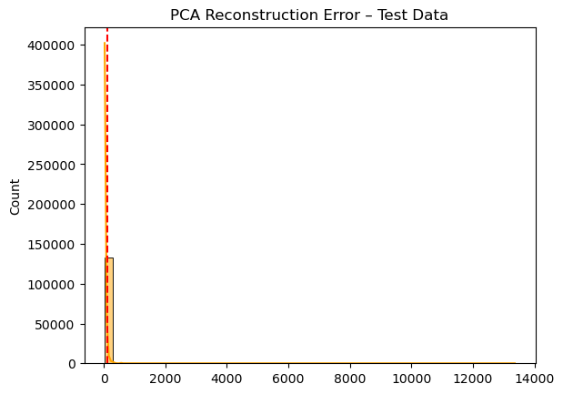

```python
sns.histplot(y_test_scores, bins=50, kde=True, color='orange')
plt.axvline(pca.threshold_, color='red', linestyle='--')
plt.title("PCA Reconstruction Error – Test Data")
```

```python
data_with_pca = data.loc[X_test.index].copy()

data_with_pca['PCA_Score'] = y_test_scores
data_with_pca['PCA_Label'] = y_test_pred
```

```python
pca_anomalies = (
    data_with_pca[data_with_pca['PCA_Label'] == 1]
    .sort_values(by='PCA_Score', ascending=False)
    [['Agency Name', 'Cardholder Last Name', 'Amount',
      'Merchant Category Code (MCC)', 'PCA_Score']]
)
cutoff = np.percentile(y_test_scores, 99.5)
data_with_pca['PCA_Label_0_5'] = (y_test_scores >= cutoff).astype(int)

print(f"Total anomalies at 0.5% threshold: {data_with_pca['PCA_Label_0_5'].sum():,}")
pca_anomalies.head(15)
```

```
Total anomalies at 0.5% threshold: 664
```

|  | Agency Name | Cardholder Last Name | Amount | Merchant Category Code (MCC) | PCA_Score |
| --- | --- | --- | --- | --- | --- |
| 14374 | OKLAHOMA STATE UNIVERSITY | Meridith | 100.00 | TOLLS AND BRIDGE FEES | 13356.956560 |
| 46511 | OKLAHOMA STATE UNIVERSITY | Hanson | 229.25 | OFFICE, PHOTOGRAPHIC, PHOTOCOPY, AND MICROFILM... | 12100.553753 |
| 21282 | OKLAHOMA STATE UNIVERSITY | Heusel | 715.00 | STATIONERY, OFFICE SUPPLIES, PRINTING AND WRIT... | 7538.275016 |
| 35161 | OKLAHOMA STATE UNIVERSITY | Davis | 62.39 | HOME SUPPLY WAREHOUSE STORES | 5659.537045 |
| 42108 | OKLAHOMA STATE UNIVERSITY | Mitchell | 24.25 | HOBBY,TOY,AND GAME STORES | 5144.407907 |
| 120950 | DEPARTMENT OF LABOR | Cobble | 526.00 | BEST WESTERN | 4458.197979 |
| 89755 | DEPARTMENT OF CORRECTIONS | Garrison | 470.22 | GOVERNMENT SERVICES--NOT ELSEWHERE CLASSIFIED | 3134.722934 |
| 22663 | OKLAHOMA STATE UNIVERSITY | Hines | 50.00 | EXTERMINATING AND DISINFECTING SERVICES | 3109.237780 |
| 28693 | OKLAHOMA STATE UNIVERSITY | Hines | 73.94 | MISCELLANEOUS AND SPECIALTY RETAIL STORES | 3108.955071 |
| 81219 | DEPARTMENT OF CORRECTIONS | Lee | 427.40 | INDUSTRIAL SUPPLIES NOT ELSEWHERE CLASSIFIED | 3108.603789 |
| 104175 | STATE DEPARTMENT OF HEALTH | Duren | 736.00 | COMPUTERS, COMPUTER PERIPHERAL EQUIPMENT, SOFT... | 2798.375433 |
| 21230 | OKLAHOMA STATE UNIVERSITY | MOTEN | 736.00 | MISCELLANEOUS PUBLISHING AND PRINTING SERVICES | 2436.859947 |
| 76346 | OFFICE OF MANAGEMENT AND ENTERPRISE SERV | Vanhorn | 53.72 | STATIONERY, OFFICE SUPPLIES, PRINTING AND WRIT... | 2432.172949 |
| 109254 | DEPARTMENT OF TRANSPORTATION | HARGUS | 67.33 | CONSTRUCTION MATERIALS NOT ELSEWHERE CLASSIFIED | 1888.222924 |
| 5680 | OKLAHOMA STATE UNIVERSITY | Hull | 34.85 | BOOK STORES | 1626.397401 |

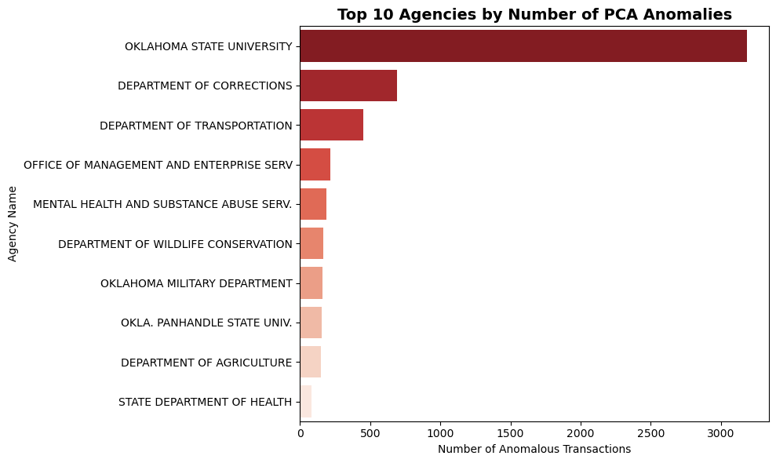

```python
agency_anomaly_counts = (
    data_with_pca[data_with_pca['PCA_Label'] == 1]
    .groupby('Agency Name')['Amount']
    .count()
    .sort_values(ascending=False)
    .head(10)
)

# Plot
plt.figure(figsize=(10,6))
sns.barplot(
    x=agency_anomaly_counts.values,
    y=agency_anomaly_counts.index,
    palette="Reds_r"
)
plt.title("Top 10 Agencies by Number of PCA Anomalies", fontsize=14, weight='bold')
plt.xlabel("Number of Anomalous Transactions")
plt.ylabel("Agency Name")
plt.tight_layout()
plt.show()
```

```python
pca_pred_saved = y_test_pred.copy()
pca_scores_saved = y_test_scores.copy()

print("PCA saved:")
print(f"  Predictions: {pca_pred_saved[:10]}")
print(f"  Scores: {pca_scores_saved[:10]}")
```

```
PCA saved:
  Predictions: [0 0 0 0 0 0 0 0 0 0]
  Scores: [39.51027333 64.20005255 85.3934408  31.86750701 55.40348546 40.13820241
 36.14945234 38.54776057 33.46633301 56.78148134]
```

## **Business Insights**

**Concentration of Anomalies in Key Agencies**

The Oklahoma State University has the most anomalous purchases, followed by the Department of Corrections and Department of Transportation. This indicates that a small number of agencies account for a disproportionate share of irregular transactions, potentially link to patterns of irregular financial reportings at these institutions.

**Repeated Anomalies Within a Single Entity** Multiple transactions from Oklahoma State University share similar merchant categories such as “Printing and Office Supplies” and “Miscellaneous Specialty Retail,” suggesting recurring inconsistencies in specific expense areas that typically do not incur large charged.

**Transaction Patterns Suggest Behavioral Irregularities** Some transactions show sudden spikes following prolonged inactivity or amounts exceeding 5× typical averages. Behavioral patterns might indicate fraudulent purchases.

# Compare two models

```python
isf_predictions = isf_pred_saved
isf_scores = isf_scores_saved


pca_predictions = y_test_pred
pca_scores = y_test_scores

cutoff_percentile = 99.5

isf_threshold = np.percentile(isf_scores, cutoff_percentile)
pca_threshold = np.percentile(pca_scores, cutoff_percentile)

isf_predictions_cutoff = (isf_scores >= isf_threshold).astype(int)
pca_predictions_cutoff = (pca_scores >= pca_threshold).astype(int)


isf_anomalies = np.sum(isf_predictions == 1)
pca_anomalies = np.sum(pca_predictions == 1)

isf_anomalies_cutoff = np.sum(isf_predictions_cutoff == 1)
pca_anomalies_cutoff = np.sum(pca_predictions_cutoff == 1)

print("="*60)
print("BASIC COMPARISON")
print("="*60)

print("\n--- ORIGINAL PREDICTIONS ---")
print(f"\nIsolation Forest:")
print(f"  - Total samples: {len(isf_predictions)}")
print(f"  - Anomalies detected: {isf_anomalies}")
print(f"  - Anomaly rate: {isf_anomalies/len(isf_predictions)*100:.2f}%")

print(f"\nPCA:")
print(f"  - Total samples: {len(pca_predictions)}")
print(f"  - Anomalies detected: {pca_anomalies}")
print(f"  - Anomaly rate: {pca_anomalies/len(pca_predictions)*100:.2f}%")

print("\n--- WITH 0.5% CUTOFF ---")
print(f"\nIsolation Forest:")
print(f"  - Threshold: {isf_threshold:.4f}")
print(f"  - Anomalies detected: {isf_anomalies_cutoff}")
print(f"  - Anomaly rate: {isf_anomalies_cutoff/len(isf_predictions_cutoff)*100:.2f}%")

print(f"\nPCA:")
print(f"  - Threshold: {pca_threshold:.4f}")
print(f"  - Anomalies detected: {pca_anomalies_cutoff}")
print(f"  - Anomaly rate: {pca_anomalies_cutoff/len(pca_predictions_cutoff)*100:.2f}%")
```

```
============================================================
BASIC COMPARISON
============================================================

--- ORIGINAL PREDICTIONS ---

Isolation Forest:
  - Total samples: 132738
  - Anomalies detected: 6464
  - Anomaly rate: 4.87%

PCA:
  - Total samples: 132738
  - Anomalies detected: 6552
  - Anomaly rate: 4.94%

--- WITH 0.5% CUTOFF ---

Isolation Forest:
  - Threshold: 4.0796
  - Anomalies detected: 664
  - Anomaly rate: 0.50%

PCA:
  - Threshold: 259.9024
  - Anomalies detected: 664
  - Anomaly rate: 0.50%
```

```python
print("\n" + "="*60)
print("SCORE STATISTICS")
print("="*60)

print(f"\nIsolation Forest Scores:")
print(f"  - Mean: {np.mean(isf_scores):.4f}")
print(f"  - Std: {np.std(isf_scores):.4f}")
print(f"  - Min: {np.min(isf_scores):.4f}")
print(f"  - Max: {np.max(isf_scores):.4f}")

print(f"\nPCA Scores:")
print(f"  - Mean: {np.mean(pca_scores):.4f}")
print(f"  - Std: {np.std(pca_scores):.4f}")
print(f"  - Min: {np.min(pca_scores):.4f}")
print(f"  - Max: {np.max(pca_scores):.4f}")
```

```
============================================================
SCORE STATISTICS
============================================================

Isolation Forest Scores:
  - Mean: -0.0048
  - Std: 0.9858
  - Min: -1.4660
  - Max: 6.9813

PCA Scores:
  - Mean: 53.4550
  - Std: 71.1218
  - Min: 26.6981
  - Max: 13356.9566
```

```python
both_anomaly = np.sum((isf_predictions == 1) & (pca_predictions == 1))
both_normal = np.sum((isf_predictions == 0) & (pca_predictions == 0))
isf_only = np.sum((isf_predictions == 1) & (pca_predictions == 0))
pca_only = np.sum((isf_predictions == 0) & (pca_predictions == 1))

total = len(isf_predictions)
agreement = (both_anomaly + both_normal) / total * 100

print("\n" + "="*60)
print("MODEL AGREEMENT")
print("="*60)
print(f"\nBoth flagged as anomaly: {both_anomaly}")
print(f"Both flagged as normal: {both_normal}")
print(f"Only ISF flagged: {isf_only}")
print(f"Only PCA flagged: {pca_only}")
print(f"\nOverall agreement: {agreement:.2f}%")
```

```
============================================================
MODEL AGREEMENT
============================================================

Both flagged as anomaly: 3440
Both flagged as normal: 123162
Only ISF flagged: 3024
Only PCA flagged: 3112

Overall agreement: 95.38%
```

```python
isf_anomaly_scores = isf_scores[isf_predictions == 1]
isf_normal_scores = isf_scores[isf_predictions == 0]

if len(isf_anomaly_scores) > 0 and len(isf_normal_scores) > 0:
    isf_separation = np.mean(isf_anomaly_scores) - np.mean(isf_normal_scores)
    isf_effect = isf_separation / np.std(isf_scores)
else:
    isf_separation = 0
    isf_effect = 0

# PCA
pca_anomaly_scores = pca_scores[pca_predictions == 1]
pca_normal_scores = pca_scores[pca_predictions == 0]

if len(pca_anomaly_scores) > 0 and len(pca_normal_scores) > 0:
    pca_separation = np.mean(pca_anomaly_scores) - np.mean(pca_normal_scores)
    pca_effect = pca_separation / np.std(pca_scores)
else:
    pca_separation = 0
    pca_effect = 0

print("\n" + "="*60)
print("SCORE SEPARATION (Higher is Better)")
print("="*60)
print(f"\nIsolation Forest:")
print(f"  - Mean anomaly score: {np.mean(isf_anomaly_scores):.4f}")
print(f"  - Mean normal score: {np.mean(isf_normal_scores):.4f}")
print(f"  - Separation: {isf_separation:.4f}")
print(f"  - Effect size: {isf_effect:.4f}")

print(f"\nPCA:")
print(f"  - Mean anomaly score: {np.mean(pca_anomaly_scores):.4f}")
print(f"  - Mean normal score: {np.mean(pca_normal_scores):.4f}")
print(f"  - Separation: {pca_separation:.4f}")
print(f"  - Effect size: {pca_effect:.4f}")
```

```
============================================================
SCORE SEPARATION (Higher is Better)
============================================================

Isolation Forest:
  - Mean anomaly score: 2.9095
  - Mean normal score: -0.1540
  - Separation: 3.0635
  - Effect size: 3.1077

PCA:
  - Mean anomaly score: 173.7125
  - Mean normal score: 47.2108
  - Separation: 126.5017
  - Effect size: 1.7787
```

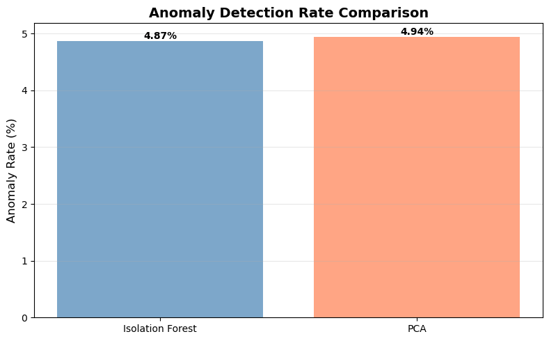

```python
fig, ax = plt.subplots(figsize=(8, 5))

models = ['Isolation Forest', 'PCA']
anomaly_rates = [isf_anomalies/len(isf_predictions)*100,
                 pca_anomalies/len(pca_predictions)*100]

bars = ax.bar(models, anomaly_rates, color=['steelblue', 'coral'], alpha=0.7)
ax.set_ylabel('Anomaly Rate (%)', fontsize=12)
ax.set_title('Anomaly Detection Rate Comparison', fontsize=14, fontweight='bold')
ax.grid(True, alpha=0.3, axis='y')

for bar, rate in zip(bars, anomaly_rates):
    height = bar.get_height()
    ax.text(bar.get_x() + bar.get_width()/2., height,
            f'{rate:.2f}%', ha='center', va='bottom', fontweight='bold')

plt.tight_layout()
plt.show()
```

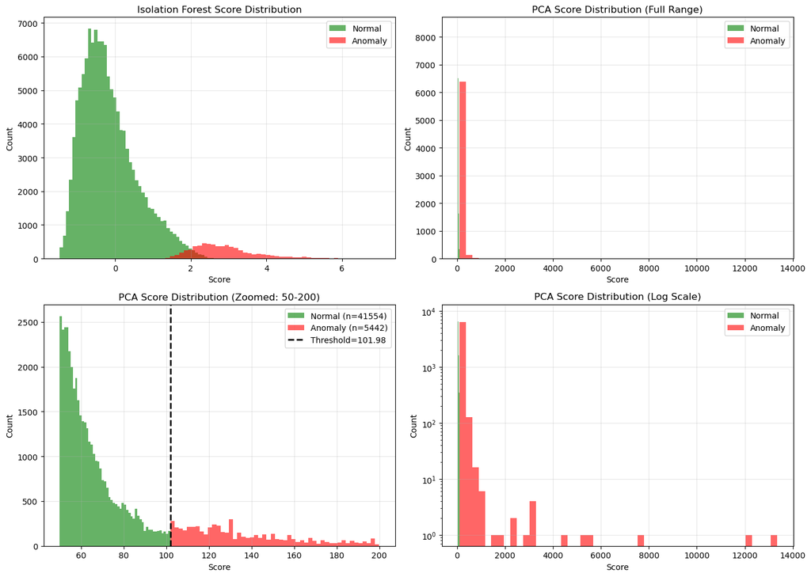

```python
fig, axes = plt.subplots(2, 2, figsize=(14, 10))

ax1 = axes[0, 0]
ax1.hist(isf_normal_scores, bins=50, alpha=0.6, label='Normal', color='green')
ax1.hist(isf_anomaly_scores, bins=50, alpha=0.6, label='Anomaly', color='red')
ax1.set_xlabel('Score')
ax1.set_ylabel('Count')
ax1.set_title('Isolation Forest Score Distribution')
ax1.legend()
ax1.grid(True, alpha=0.3)

ax2 = axes[0, 1]
ax2.hist(pca_normal_scores, bins=50, alpha=0.6, label='Normal', color='green')
ax2.hist(pca_anomaly_scores, bins=50, alpha=0.6, label='Anomaly', color='red')
ax2.set_xlabel('Score')
ax2.set_ylabel('Count')
ax2.set_title('PCA Score Distribution (Full Range)')
ax2.legend()
ax2.grid(True, alpha=0.3)

ax3 = axes[1, 0]
threshold_range = pca_scores[(pca_scores > 50) & (pca_scores < 200)]
normal_zoom = pca_normal_scores[(pca_normal_scores > 50) & (pca_normal_scores < 200)]
anomaly_zoom = pca_anomaly_scores[(pca_anomaly_scores > 50) & (pca_anomaly_scores < 200)]

ax3.hist(normal_zoom, bins=50, alpha=0.6, label=f'Normal (n={len(normal_zoom)})', color='green')
ax3.hist(anomaly_zoom, bins=50, alpha=0.6, label=f'Anomaly (n={len(anomaly_zoom)})', color='red')
ax3.axvline(pca.threshold_, color='black', linestyle='--', linewidth=2, label=f'Threshold={pca.threshold_:.2f}')
ax3.set_xlabel('Score')
ax3.set_ylabel('Count')
ax3.set_title('PCA Score Distribution (Zoomed: 50-200)')
ax3.legend()
ax3.grid(True, alpha=0.3)

ax4 = axes[1, 1]
ax4.hist(pca_normal_scores, bins=50, alpha=0.6, label='Normal', color='green')
ax4.hist(pca_anomaly_scores, bins=50, alpha=0.6, label='Anomaly', color='red')
ax4.set_xlabel('Score')
ax4.set_ylabel('Count')
ax4.set_title('PCA Score Distribution (Log Scale)')
ax4.set_yscale('log')
ax4.legend()
ax4.grid(True, alpha=0.3)

plt.tight_layout()
plt.show()
```

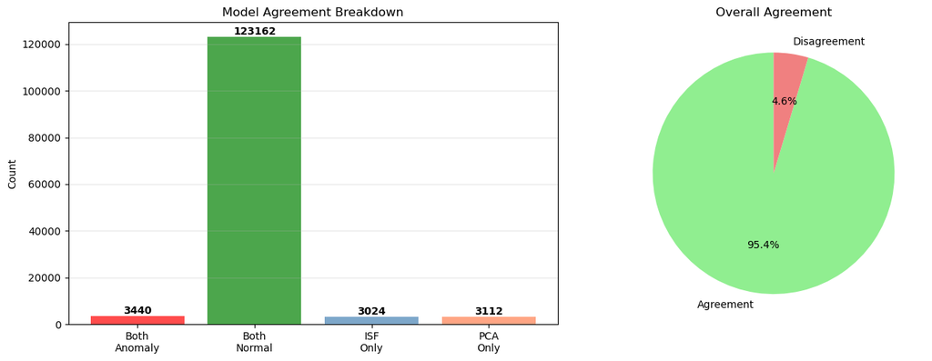

```python
fig, (ax1, ax2) = plt.subplots(1, 2, figsize=(14, 5))

categories = ['Both\nAnomaly', 'Both\nNormal', 'ISF\nOnly', 'PCA\nOnly']
values = [both_anomaly, both_normal, isf_only, pca_only]
colors = ['red', 'green', 'steelblue', 'coral']

bars = ax1.bar(categories, values, color=colors, alpha=0.7)
ax1.set_ylabel('Count')
ax1.set_title('Model Agreement Breakdown')
ax1.grid(True, alpha=0.3, axis='y')

for bar, val in zip(bars, values):
    height = bar.get_height()
    ax1.text(bar.get_x() + bar.get_width()/2., height,
            str(val), ha='center', va='bottom', fontweight='bold')

ax2.pie([both_anomaly + both_normal, isf_only + pca_only],
        labels=['Agreement', 'Disagreement'],
        autopct='%1.1f%%',
        colors=['lightgreen', 'lightcoral'],
        startangle=90)
ax2.set_title('Overall Agreement')

plt.tight_layout()
plt.show()
```

```python
print("\n" + "="*60)
print("RECOMMENDATION")
print("="*60)

if abs(isf_effect) > abs(pca_effect):
    better_model = "Isolation Forest"
    better_effect = isf_effect
else:
    better_model = "PCA"
    better_effect = pca_effect

print(f"\n✓ Better separation: {better_model}")
print(f"  Effect size: {better_effect:.4f}")

if agreement > 70:
    print(f"\n✓ High agreement ({agreement:.1f}%)")
    print("  → Models are consistent, choose based on:")
else:
    print(f"\n⚠ Low agreement ({agreement:.1f}%)")
    print("  → Models capture different patterns")

print(f"\n✓ High-confidence anomalies: {both_anomaly}")
print("  (Flagged by both models)")

print("\n" + "="*60)
```

```
============================================================
RECOMMENDATION
============================================================

✓ Better separation: Isolation Forest
  Effect size: 3.1077

✓ High agreement (95.4%)
  → Models are consistent, choose based on:

✓ High-confidence anomalies: 3440
  (Flagged by both models)

============================================================
```